# Chap15

202140191 엄태훈

2021-04-30(Fri)

# Chap15 Bivariate Statistics-Discrete Data

## Mosaic Plot

모자이크 플랏(mosaic plot)은 교차표를 시각화한 그래프이다.  
모자이크 플랏에는 사각형들로 표현이 되며, 사각형의 크기는 데이터의 비율을 의미한다.  
R에서는 `mosaicplot`함수를 이용하여 쉽게 그릴 수 있다.  
Formula를 이용하여 교차표의 데이터를 어떤 방식으로 나눌지 지정할 수 있다.

```r
library(HH)
library(vcd)
library(dplyr)
```

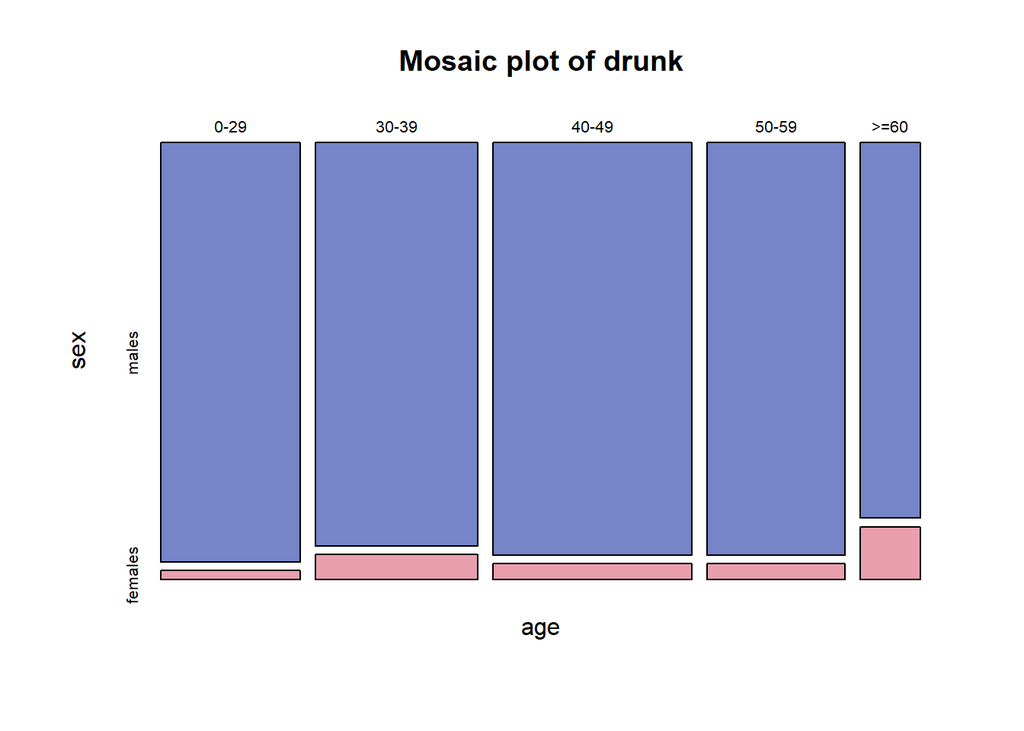

```r
data(drunk)
mosaicplot(~age+sex,data=drunk,main="Mosaic plot of drunk",color=c("#7685C8","#E99FAD"))
```

파란색 사각형이 빨간색 사각형의 크기에 비해서 월등하게 큰 것을 확인할 수 있다.  
파란색 사각형은 male의 비율, 빨간색 사각형은 Female의 비율을 나타낸다.  
남성의 경우, 40~49세의 사각형이 가장 큰 것으로 보아 40~49세가 음주빈도가 가장 높은 연령대인 것을 알 수 있고 여성의 경우, 30~39세의 사각형이 가장 큰 것으로 보아 30~39세가 음주빈도가 가장 높은 연령대인 것을 확인할 수 있다.

## Mosaic

Mosaicplot 함수말고도 mosaic 함수를 통해서도 mosaic plot을 그릴 수 있다.  
mosaic함수는 `vcd`패키지를 설치해야 한다.  
mosaic함수는 특이하게 shade라는 옵션을 제공한다.  
shade 옵션은 관찰빈도와 기대빈도의 관계를 보여주며, 오른쪽 아래 chi-test의 결과에 대한 P-value도 제공한다.

```r
data("Titanic")
Titanic
```

```
## , , Age = Child, Survived = No
##
##       Sex
## Class  Male Female
##   1st     0      0
##   2nd     0      0
##   3rd    35     17
##   Crew    0      0
##
## , , Age = Adult, Survived = No
##
##       Sex
## Class  Male Female
##   1st   118      4
##   2nd   154     13
##   3rd   387     89
##   Crew  670      3
##
## , , Age = Child, Survived = Yes
##
##       Sex
## Class  Male Female
##   1st     5      1
##   2nd    11     13
##   3rd    13     14
##   Crew    0      0
##
## , , Age = Adult, Survived = Yes
##
##       Sex
## Class  Male Female
##   1st    57    140
##   2nd    14     80
##   3rd    75     76
##   Crew  192     20
```

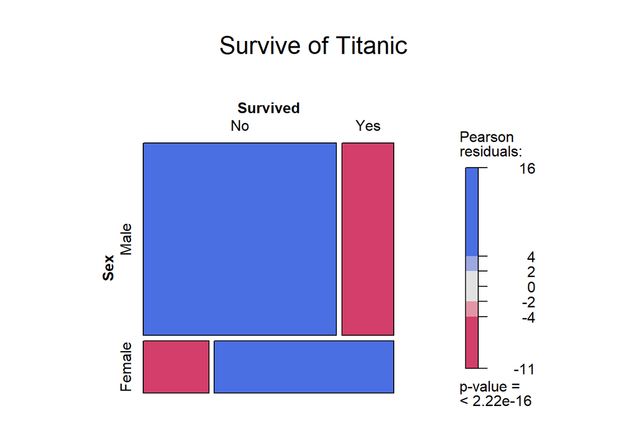

```r
mosaic(~Sex+Survived,data=Titanic,main="Survive of Titanic",color=c("#7685C8","#E99FAD"),shade=TRUE)
```

P-value가 유의수준 0.05보다 작으므로 귀무가설을 기각한다. 따라서 두 변수는 연관성이 있다고 할 수 있다.(독립X)  
파란색으로 사각형이 채워진 경우, 관찰빈도가 기대빈도보다 높다는 의미이고,  
빨간색으로 사각형이 채워진 경우, 관찰빈도가 기대빈도보다 낮다는 의미이다.  
즉, 남성이 생존하지 못할 관찰빈도가 기대빈도보다 높다는 의미로 해석할 수 있고  
여성의 경우 생존하지 못할 관찰빈도가 기대빈도보다 낮다는 의미로 해석할 수 있다.

## 다중 mosaic plot

앞서 본 예제처럼 범주가 두 가지인 경우가 아니라 세 가지 이상인 경우도 많다.  
이런 경우, 기본옵션만으로 mosaicplot을 그리게 되면 원하는 결과를 얻기 힘들기 때문에 옵션을 지정해 줘야한다.  
`highlighting`옵션은 어떠한 변수를 기준으로 색깔을 나눌것인지를 결정하는 것이다.  
`highlighting_fill` 옵션은 나눠지는 변수들에 대해서 색깔을 지정해주는 옵션이다.  
`direction`옵션은 변수의 축을 어떻게 할지 정해주는 것이다. h = horizontal, v = vertical을 의미한다.

```r
data(salk)
salk
```

```
##      age vaccine paralyze Freq
## 1    0-4     vac   no.par   20
## 2    0-4     vac      par   14
## 3    0-4  no.vac   no.par   10
## 4    0-4  no.vac      par   24
## 5    5-9     vac   no.par   15
## 6    5-9     vac      par   12
## 7    5-9  no.vac   no.par    3
## 8    5-9  no.vac      par   15
## 9  10-14     vac   no.par    3
## 10 10-14     vac      par    2
## 11 10-14  no.vac   no.par    3
## 12 10-14  no.vac      par    2
## 13 15-19     vac   no.par    7
## 14 15-19     vac      par    4
## 15 15-19  no.vac   no.par    1
## 16 15-19  no.vac      par    6
## 17 20-39     vac   no.par   12
## 18 20-39     vac      par    3
## 19 20-39  no.vac   no.par    7
## 20 20-39  no.vac      par    5
## 21   40+     vac   no.par    1
## 22   40+     vac      par    0
## 23   40+  no.vac   no.par    3
## 24   40+  no.vac      par    2
```

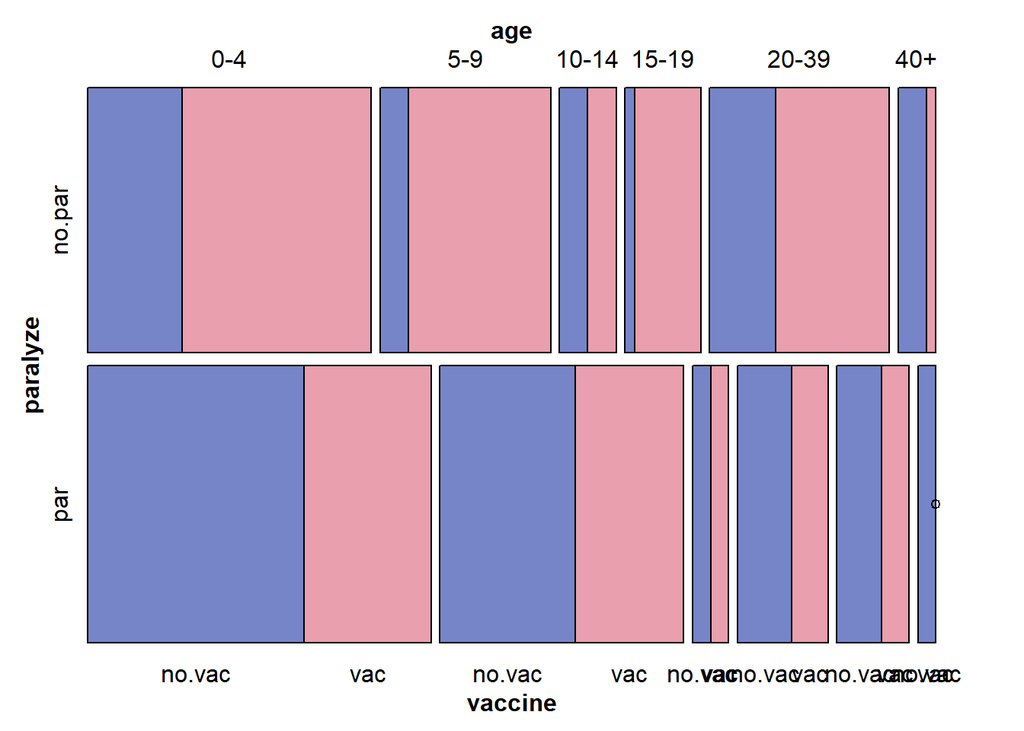

```r
mosaic(~paralyze+age+vaccine,data=salk,highlighting = "vaccine",highlighting_fill=c("#7685C8","#E99FAD"),
       direction=c("h","v","v"))
```

우리가 지정한 vaccine의 여부에 따라서 색깔이 나누어졌고, 지정한 컬러로 다중 모자이크 플랏이 만들어졌다.  
또한 paralyze 변수의 경우 축을 horizontal으로 지정했기 때문에 옆으로 누워있는 것을 확인할 수 있다.

## assoc function

`vec` 패키지의 assoc를 이용하면 assocplot을 그릴 수 있다.  
assocplot 또한 교차표를 그래프를 통해 살펴봄으로써 데이터의 형태를 조금 더 쉽게 볼 수 있다.  
assoc함수 또한 Formula를 이용하여 시각화할 데이터를 지정해준다. assoc함수에서 그래프의 색깔을 채우기 위해서는 `gp=gpar(fill=c("색깔","색깔"))` 옵션을 이용한다.

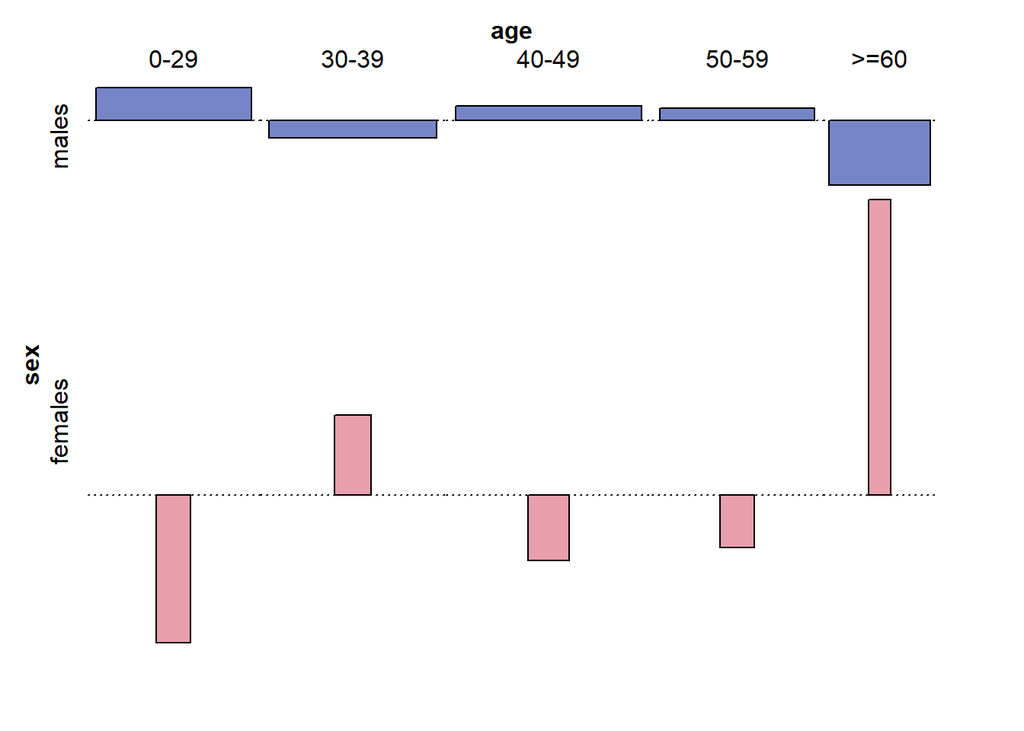

```r
assoc(age~sex,data=drunk,gp=gpar(fill=c("#7685C8","#E99FAD")))
```

fill 옵션이 아닌 `col` 옵션을 이용하면 테두리에 색깔을 채우게 된다.

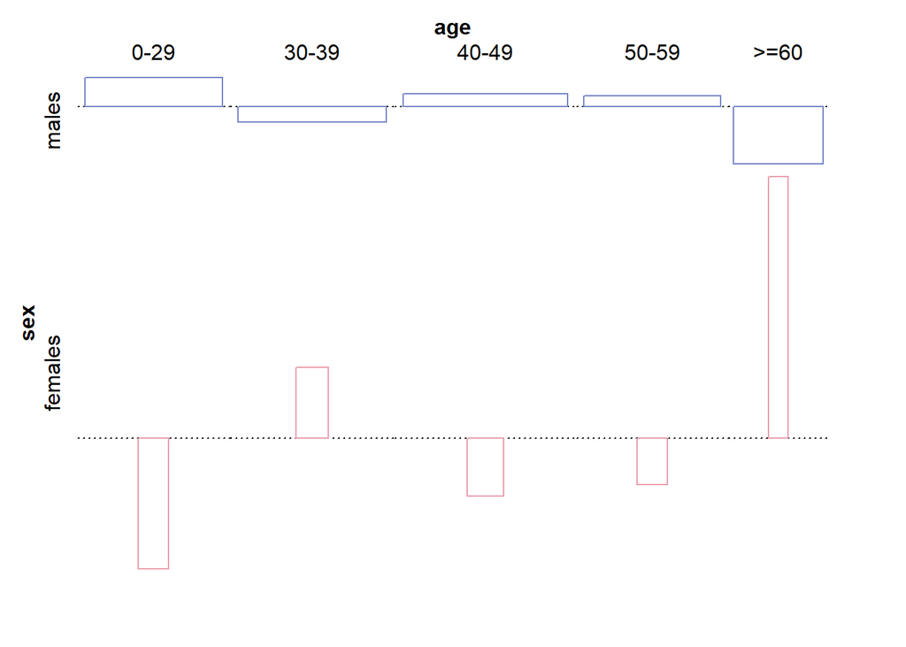

```r
assoc(age~sex,data=drunk,gp=gpar(col=c("#7685C8","#E99FAD")))
```

`gp=shading_binary` 옵션을 통해 mosaic plot에서도 제공했던 shade 옵션을 사용할 수 있다.  
mosaic plot에서와 같이 관찰빈도와 기대빈도의 관계를 살펴볼 수 있다.

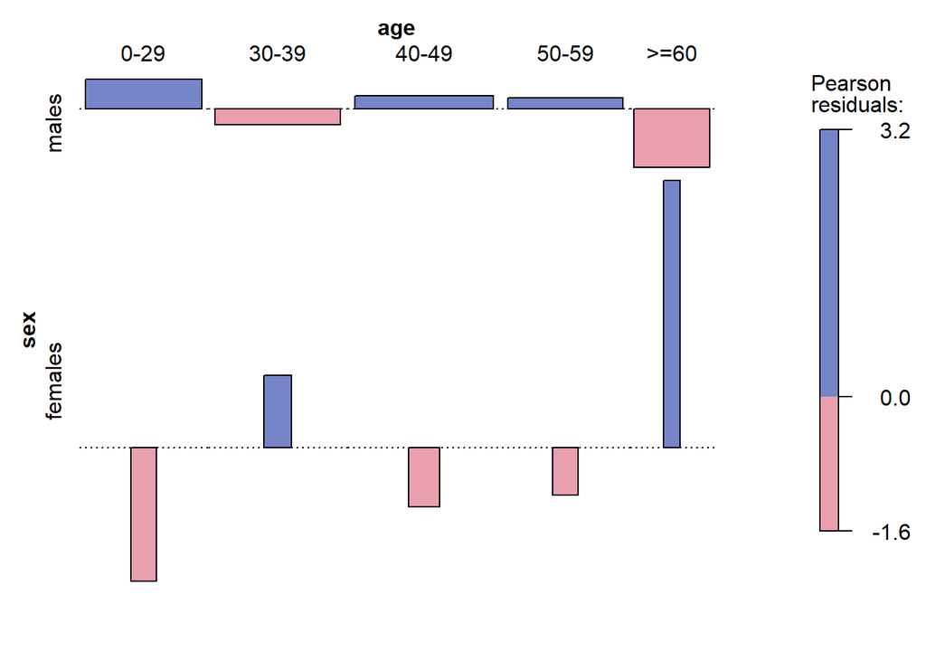

```r
assoc(age~sex,data=drunk,gp=shading_binary(col=c("#7685C8","#E99FAD")))
```

## cotabplot

cotabplot을 이용하면 xyplot과 같이 조건부 시각화 그림을 그릴 수 있다.  
아래에서는 Formula를 지정한 후 |sex라는 옵션을 지정하여 성별에 따라서 그래프를 나눠서 그렸다.

```r
drunk.chisq <- chisq.test(drunk)
```

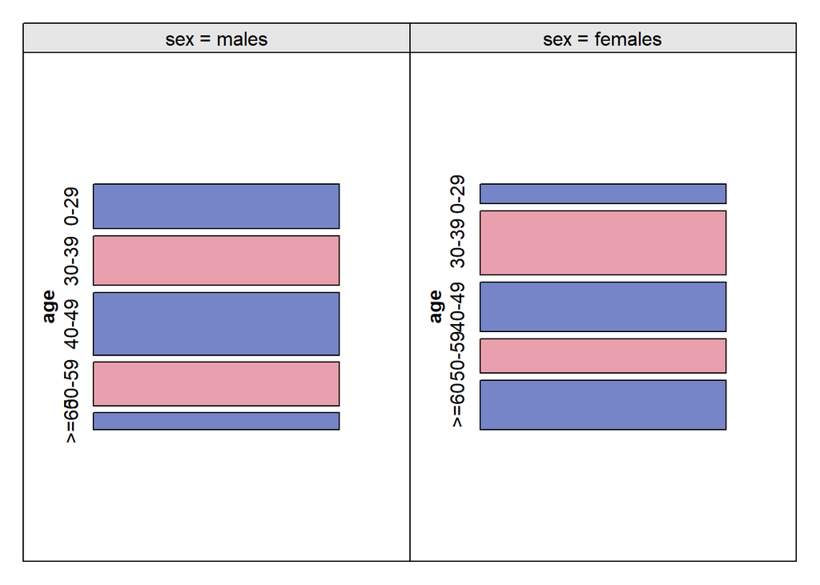

```r
cotabplot(~age|sex,data=drunk,gp=gpar(fill=c("#7685C8","#E99FAD")))
```

## chisq.test in R

R에서는 chisq.test를 통해 간단하게 독립성 검정을 진행할 수 있다.  
H0: 두 변수들은 연관성이 없으며 서로 독립이다.  
H1: 두 변수들은 연관성이 있으며 서로 독립이아니다.

```r
drunk.chisq <- chisq.test(drunk)
drunk.chisq
```

```
##
##  Pearson's Chi-squared test
##
## data:  drunk
## X-squared = 15.246, df = 4, p-value = 0.004217
```

P-value = 0.004217로 유의수준 0.05보다 작으므로 두 변수들은 연관성이 있다고 할 수 있다.

Chi-squared test를 객체에 저장하게 되면 카이제곱 통계랑과 P-value 뿐만 아니라 다른 정보들도 살펴볼 수 있다.

```r
# observed에는 주어진 교차표의 관찰값들이 들어가있다.
drunk.chisq$observed
```

```
##          age
## sex       0-29 30-39 40-49 50-59 >=60
##   males    185   207   260   180   71
##   females    4    13    10     7   10
```

```r
# expected에는 주어진 교차표의 기댓값들이 들어가있다.
drunk.chisq$expected
```

```
##          age
## sex             0-29     30-39     40-49     50-59      >=60
##   males   180.218585 209.77825 257.45512 178.31151 77.236536
##   females   8.781415  10.22175  12.54488   8.68849  3.763464
```

```r
# rsiduals에는 주어진 교차표들의 잔차를 포함한다.
drunk.chisq$residuals
```

```
##          age
## sex             0-29      30-39      40-49      50-59       >=60
##   males    0.3561694 -0.1918186  0.1586048  0.1264471 -0.7096302
##   females -1.6135194  0.8689768 -0.7185117 -0.5728308  3.2147678
```

```r
# 잔차^2을 하게되면 각 잔체의 제곱 값을 확인할 수 있다.
drunk.chisq$residuals^2
```

```
##          age
## sex              0-29       30-39       40-49       50-59        >=60
##   males    0.12685667  0.03679436  0.02515548  0.01598886  0.50357497
##   females  2.60344482  0.75512067  0.51625904  0.32813508 10.33473181
```

## Two-Dimensional Contingency Tables - Fisher’s Exact Test

## Example-Do Juvenile Delinquents Eschew Wearing Eyeglasses?

앞서 우리는 두 범주형 변수 간에 연관성을 확인하기 위해 카이제곱 검정을 실시하였다.  
그러나 만약 교차표에서 기대빈도가 5보다 작은 셀이 20%이상인 경우,  
카이제곱 검정보다 Fisher’s exact test를 수행하는 것이 좋다.

H0: 두 변수들은 연관성이 없으며 서로 독립이다.  
H1: 두 변수들은 연관성이 있으며 서로 독립이아니다.

```r
data(glasses)
fisher.test(glasses)
```

```
##
##  Fisher's Exact Test for Count Data
##
## data:  glasses
## p-value = 0.03497
## alternative hypothesis: true odds ratio is not equal to 1
## 95 percent confidence interval:
##  0.0009525702 0.9912282442
## sample estimates:
## odds ratio
## 0.06464255
```

P-value = 0.03497로 유의수준 0.05보다 작으므로 두 변수들은 관련성이 있다고 할 수 있다.

## AEdotplot

`HH` 패키지에 내장돼있는 `AEdotplot`은 데이터의 다양한 정보들을 패널을 나눔으로써 확인할 수 있게 해준다.  
여기서 사용한 AEdata는 암에 관련된 데이터이다.  
첫 번째 패널은 그룹별로 발생률을 표시하고 기호를 통해 그룹을 구분해준다.  
두 번째 패널은 95% 신뢰구간을 사용하여 암에 대한 상대적 위험을 표시한다.  
세 번째 패널에서는 각 치료에 대한 환자 수, 각 치료에 대한 부작용 수 및 상대적 위험이 표시된다.

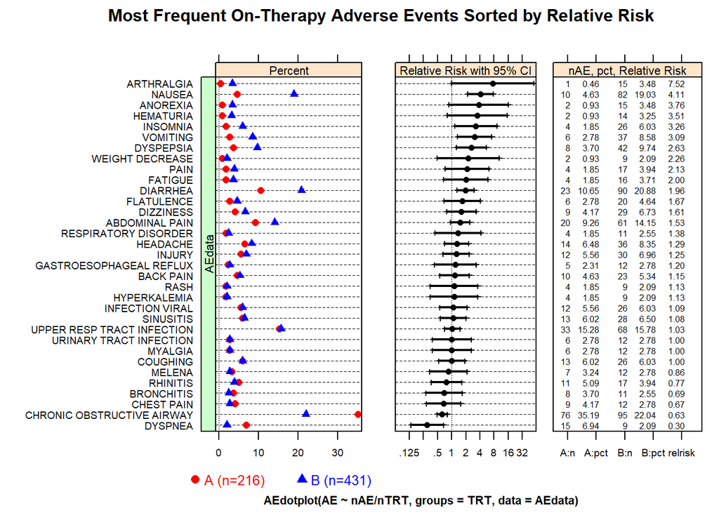

```r
library(HH)
data(AEdata)
AEdotplot(AE~nAE/nTRT,groups=TRT,data=AEdata)
```

## stacked plot

barplot 함수에 table 데이터를 넣게 되면 자동으로 교차표에 따른 stack plot을 그려준다.  
`beside=FALSE`옵션을 지정하게 되면 Stacked 막대그림,  
`beside=TRUE`옵션을 지정하게 되면 Side형 막대그림을 그릴 수 있다.

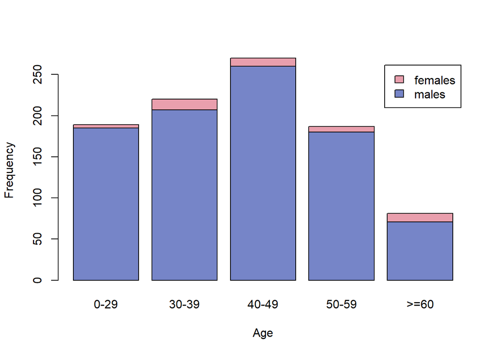

```r
data(drunk)
barplot(drunk,col=c("#7685C8","#E99FAD"),legend = c('males','females'),
xlab="Age",ylab="Frequency",beside=FALSE)
```

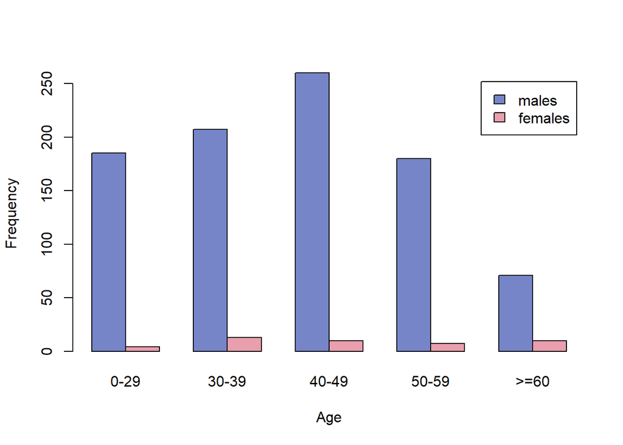

```r
data(drunk)
barplot(drunk,col=c("#7685C8","#E99FAD"),legend = c('males','females'),
xlab="Age",ylab="Frequency",beside=TRUE)
```

## Waffle plot

`waffle plot`또한 각 범주의 빈도수를 시각화 하기에 좋은 방법이다.  
시각화 된 결과가 Waffle과 비슷하여 `Waffle plot`이라는 이름이 붙었다고 한다.

Cyl에 따른 차량의 개수를 파악하기 위해 dplyr함수를 통해 전처리를 진행해주었다.

```r
data(mtcars)
Cyl_freq <- mtcars %>%
  group_by(cyl) %>%
  summarise(count=n())
```

`Waffle`함수는 빈도수를 가지고 있는 열을 입력해주면 쉽게 그릴 수 있다.  
- rows: 가로의 갯수를 지정한다.

```r
library(waffle)
```

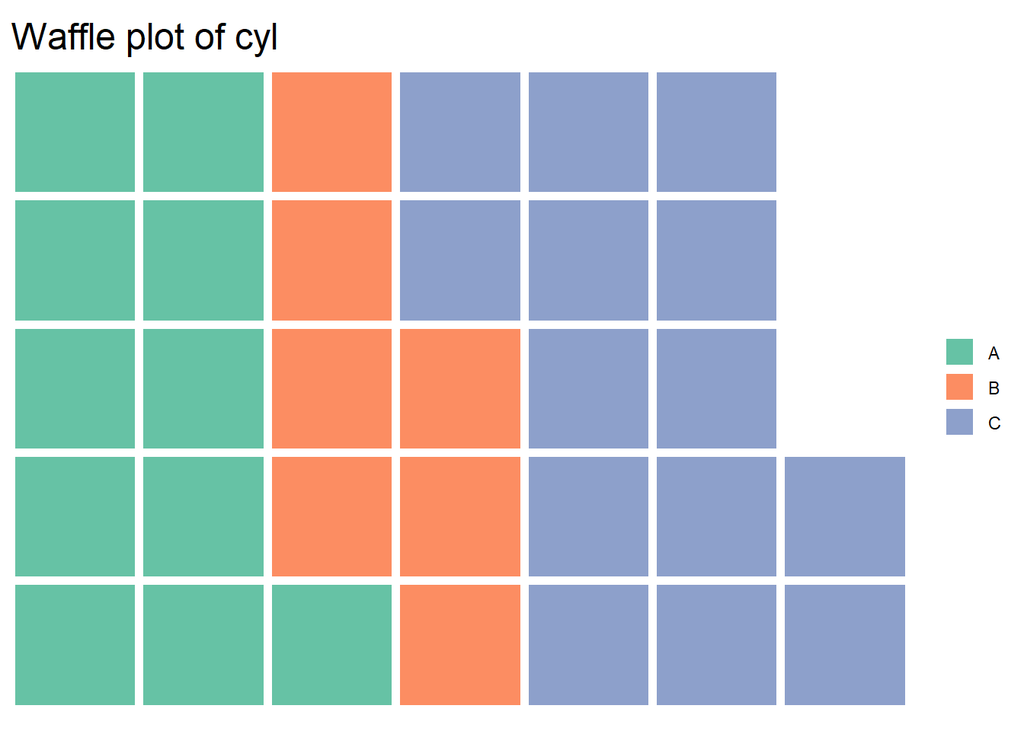

```r
waffle(Cyl_freq$count,rows=5,title="Waffle plot of cyl")
```

범례의 이름을 지정하기 위해서는 데이터를 넣을 때 `항목 이름 = 숫자`형태로 넣으면 된다.

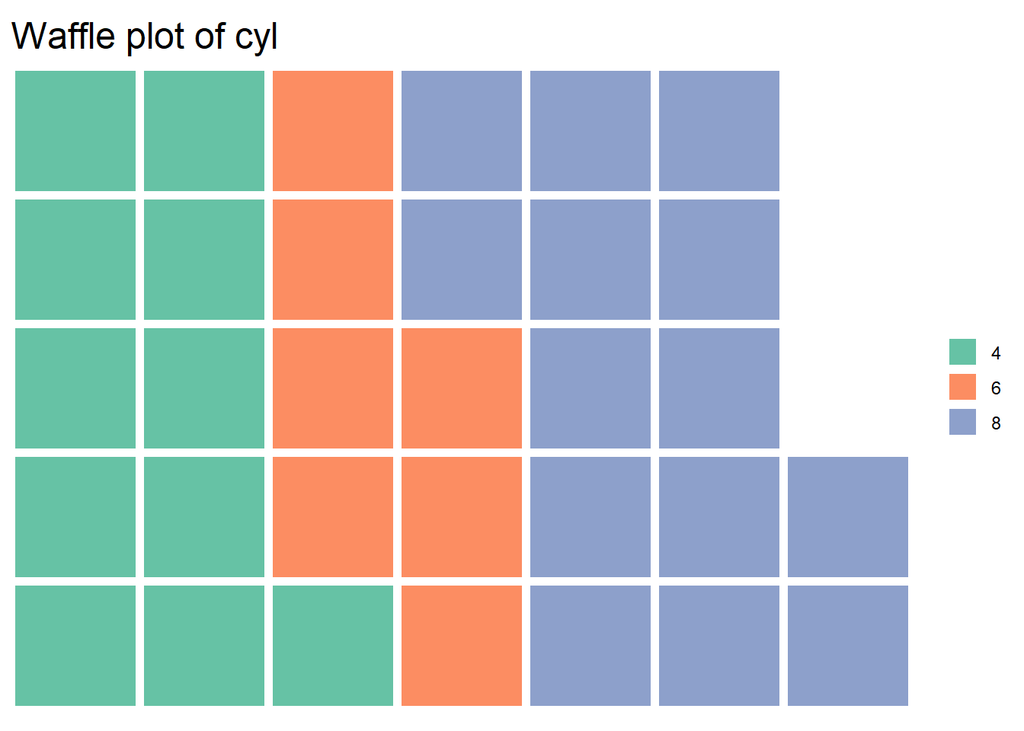

```r
library(waffle)
waffle(c("4"=11,"6"=7,"8"=14),rows=5,title="Waffle plot of cyl")
```

waffle plot을 그릴 때 네모난 모양이 아닌 자기가 원하는 그림을 그리고 싶은 경우가 있을 수 있다.  
이러한 경우, R과 호환되는 Font-Awesome을 다운 받은 후 R에 추가하는 작업을 거쳐야 한다.

1. font를 불러오기 위해 `extrafont`패키지를 설치한다.
2. *https://github.com/FortAwesome/Font-Awesome/releases/tag/v4.7.0* 링크에서 fontawesome을 다운받는다.  
   ! 폰트를 다운받은 후 반드시 폰트를 설치해줘야 한다.

```r
library(extrafont)
```

3. `font_import`를 통해 다운받은 폰트를 import한다.
- *path*: 폰트를 설치한 위치.
- *pattern*: 지정한 경로에 파일이 많을 경우 시간이 오래걸리므로 지정한 이름으로 시작하는 파일만 불러온다.  
  폰트를 import 한 후 font의 Familyname과 FontName, Fontfile을 살펴본다.

```r
font_import(path="C:\\Users\\eum20\\Downloads",pattern="fontawesome-",prompt = FALSE)
```

```
## Scanning ttf files in C:\Users\eum20\Downloads ...
```

```
## Extracting .afm files from .ttf files...
```

[output not shown]

```r
fonttable() %>%
  as_tibble() %>%
  filter(grepl("Awesom", FamilyName)) %>%
  select(FamilyName, FontName, fontfile)
```

```
## # A tibble: 3 x 3
##   FamilyName  FontName   fontfile
##   <chr>       <chr>      <chr>
## 1 FontAwesome FontAweso~ "C:\\Users\\eum20\\Downloads\\Font-Awesome-4.7.0\\Font~
## 2 FontAwesome FontAweso~ "C:\\Users\\eum20\\Downloads\\Font-Awesome-4.7.0\\Font~
## 3 FontAwesome FontAweso~ "C:\\Users\\eum20\\Downloads\\Font-Awesome-4.7.0\\Font~
```

4. `load_fontawesome`을 이용하여 설치된 폰트를 로드한다. (*emojifont*패키지를 이용한다.)

```r
library(emojifont)
load.fontawesome(font = "fontawesome-webfont.ttf")
```

5. `showtext`패키지에 있는 `font_add`를 이용하여 폰트를 R에 내장시켜준다.

```r
library(showtext)
font_add(family = "FontAwesome", regular = "C:\\Users\\eum20\\Downloads\\fontawesome-webfont.ttf")
showtext_auto()
```

6. `waffle`함수의 *use_glyph*를 이용하여 원하는 그림을 넣는다.
- *use_glyph* = 원하는 픽토그램의 모양
- *glyph_size* = 원하는 픽토그램의 사이즈

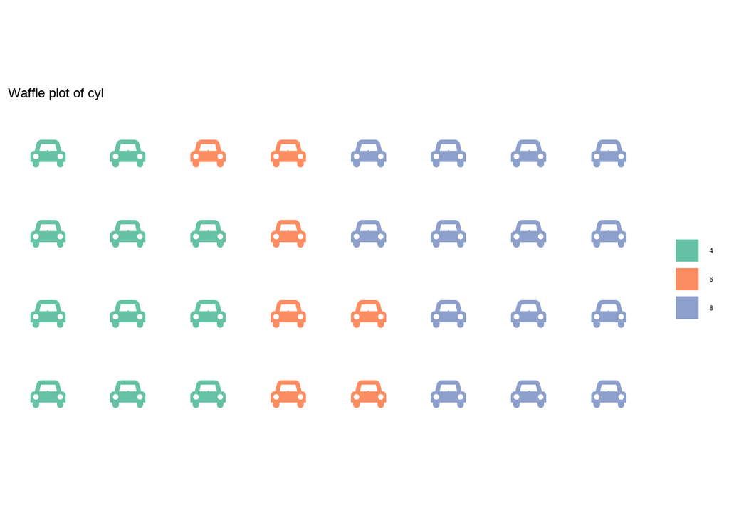

```r
waffle(c("4"=11,"6"=7,"8"=14),rows=4,title="Waffle plot of cyl",use_glyph="car",glyph_size=15)
```

[figure not shown]

```r
waffle(c("Red"=18,"Green"=12),rows=5,title="Number of Apple",use_glyph="apple",glyph_size=15,
       colors=c("#FF9090","#B7F0B1"))
```

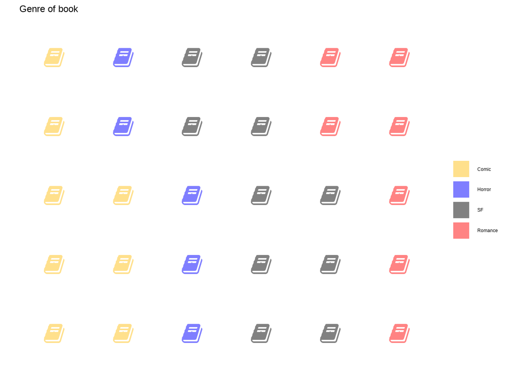

```r
waffle(c("Comic"=8,"Horror"=5,"SF"=10,"Romance"=7),rows=5,title="Genre of book",use_glyph="book",glyph_size=15,
       colors=c("#FFE08C","#7F7EFF","#818181","#FF8383"))
```

앞선 waffle 그림보다 훨씬 그림이 한 눈에 들어오는 것을 확인할 수 있다.

`iron` 함수를 이용하면 픽토그램의 모양을 여러개로 지정하여 한 그래프 안에 그릴 수 있다.

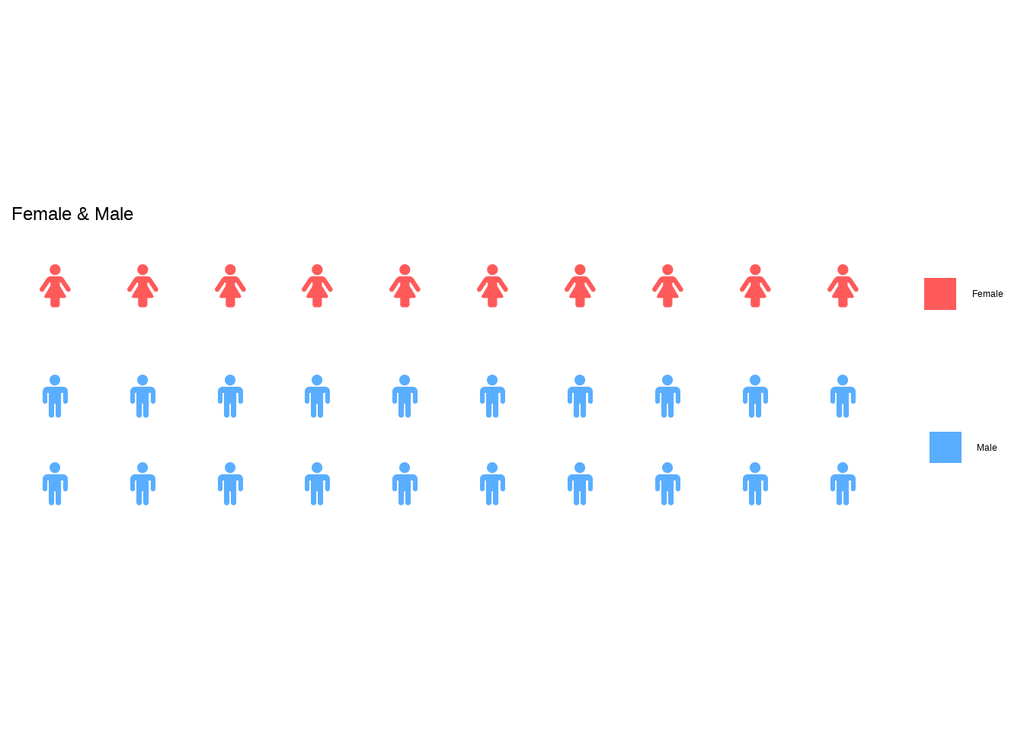

```r
iron(waffle(c('Female'=10),colors="#FF5A5A",use_glyph = "female",glyph_size = 15,rows=1,title="Female & Male"),
waffle(c('Male'=20),colors="#5AAEFF",use_glyph = "male",glyph_size = 15,rows=2))
```

## Bubble chart

`Bubble chart`는 데이터의 크기에 따라 그래프의 모양을 다르게 해주는 그림이다.  
즉, 비중이 높을수록 그래프의 크기가 더욱 커진다.

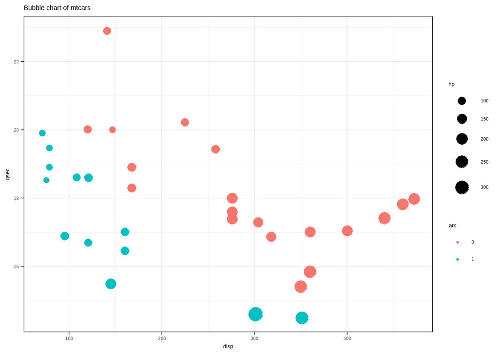

```r
mtcars$am <- as.factor(mtcars$am)
ggplot(mtcars,aes(x=disp,y=qsec,colour=am))+
  scale_size_area(max_size=10)+
  geom_point(aes(size=hp),shape=20)+
  ggtitle("Bubble chart of mtcars")+
  theme_bw()
```

x축은 mtcars의 disp, y축은 mtcars의 qsec로 나타내었다.  
차량의 기어가 automatic인지, manual인지에 따라서 색깔을 구분해주었고 (Auto=0,Manual=1)  
bubble의 크기는 hp에 따라서 크기를 다르게 하였다.

# Summary of Chapter15

- R에서는 다양한 형태의 데이터 자료 구조를 만들 수 있는데 대표적으로 많이 사용되는 구조는 행과 열로 이루어진 **data.frame** 구조이다. 우리가 가지고 있는 거의 모든 데이터들은 관측치를 가지고 있는 행과 변수를 나타내는 열로 구성되어 있기 때문에 R에서 **data.frame**구조를 이용하면 데이터를 쉽게 불러오고 분석하기 용이한 구조로 만들 수 있다.
- **교차표**는 범주형 변수들의 조합에 따른 빈도를 표로 나타낸 것을 말한다. 이러한 데이터 형태를 R에서는 **table 데이터**라고 한다. table 데이터의 경우 데이터 프레임에 비해서 다루기가 쉽지않기 때문에 적절한 전처리와 분석방법을 이용하는 것이 좋다. 특히, R의 `unlist`함수를 이용하면 조금 더 쉽게 table 데이터를 처리할 수 있다.
- 교차표 같은 경우, 빈도와 범주로 구성돼 있기 때문에 요약된 표를 통해서는 한 눈에 차이를 살펴보기 어렵다. 따라서, 시각화 기법을 이용해 결과를 정리하는 것이 중요하다. 대표적인 예시로는 `barplot`, `pieplot`등을 예시로 들 수 있다.
- **모자이크 플랏(Mosaic plot)**은 두 개 이상의 다변량 범주형 자료를 시각화 하는 기법 중 하나이다. 범주에 따라서 색깔이 달라지고 빈도에 따라서 사각형의 넓이가 달라지기 때문에 barplot, pieplot에 비해서 데이터가 내포하고 있는 정보를 조금 더 쉽게 얻을 수 있다는 장점이 있다.
- 앞에서 살펴본 그림 외에도 교차표를 시각화 할 수 있는 방법과 함수는 상당히 많다. 범주와 빈도를 시각화할 수 있는 많은 방법들을 찾아보고 데이터 특징과 분석 상황에 맞는 적절한 그래프를 그릴 수 있게 연습하는 것이 좋다.
- **적합도 검정(Goodness of fit test)**는 관측값들이 어떤 이론적인 특정 분포를 따르고 있는지를 검정하는 것이다. 보통 한 개의 요인을 대상으로 하는 경우가 많다.
- **적합도 검정**의 귀무가설과 대립 가설은 다음과 같다.  
  -귀무가설 H0: 관측값의 도수와 가정한 이론 도수가 동일하다. (관측값이 특정 분포를 따른다.)  
  -대립가설 H1: 적어도 하나의 범주 (혹은 계급)의 도수가 가정한 이론도수(기대 관측도수)와 다르다. (관측값이 특정 분포를 따르지 않는다.)
- **독립성 검정**은 서로 다른 요인들에 의해 분할되어 있는 경우 그 요인들이 관찰값에 영향을 주고 있는지 아닌지, 요인들이 서로 연관이 있는지 없는지를 검정하는 것을 말한다.
- **독립성 검정의** 가설은 다음과 같다. -귀무가설 H0: 두 변수 X와 Y는 서로 독립이다.(관련성이 없다.) -대립가설 H1: 두 변수 X와 Y는 서로 독립이 아니다.(관련성이 있다.)